# Intro to R

## Структуры данных

### Вектор

Это самая базовая, простая структура. Вектор - это последовательность элементов одного и того же типа. Вектор можно создать командой конкатенации `с()`:

```r
a<-c(1,2,3,3,2,1)

a
```

```
## [1] 1 2 3 3 2 1
```

С числовыми векторами можно осуществлять самые разные преобразования. Благодаря векторизованности языка R, нам нет необходимости писать цикл, который будет применять операции к каждому елементу вектора. R это сделает сам.

- арифметические операции

```r
a*2
```

```
## [1] 2 4 6 6 4 2
```

```r
a*c(1,2,3,4)
```

```
## [1]  1  4  9 12  2  2
```

```r
a-5
```

```
## [1] -4 -3 -2 -2 -3 -4
```

```r
a^2
```

```
## [1] 1 4 9 9 4 1
```

```r
a/2
```

```
## [1] 0.5 1.0 1.5 1.5 1.0 0.5
```

```r
a*c(1,2,3,4,5,6)
```

```
## [1]  1  4  9 12 10  6
```

- операции сравнения (важно! `=` - оператор присваивания! для сравнения используйте `==`)

```r
a<=1
```

```
## [1]  TRUE FALSE FALSE FALSE FALSE  TRUE
```

```r
a!=1
```

```
## [1] FALSE  TRUE  TRUE  TRUE  TRUE FALSE
```

```r
a==1
```

```
## [1]  TRUE FALSE FALSE FALSE FALSE  TRUE
```

В результате мы получаем вектор логических значений. Запомним, это пригодится нам далее.

Вспомним, что в логических переменных `TRUE=1`, `FALSE=0`

```r
tf = c(TRUE,TRUE,FALSE,TRUE)
tf == 1
```

```
## [1]  TRUE  TRUE FALSE  TRUE
```

```r
tf == 0
```

```
## [1] FALSE FALSE  TRUE FALSE
```

```r
sum(tf)
```

```
## [1] 3
```

```r
sum(tf == 0)
```

```
## [1] 1
```

Наш датасет, хранящийся в data, имеет 15 столбиков. Каждый столбик - это вектор. Мы можем извлекать их оттуда через знак $:

```r
data2$height
```

```
##  [1] 165 180 161 164 180 170 170 173 163 168 165 164 166  NA 173 173 183 170 185
## [20] 169 185 172 158 185 168 175 162 182 164 167 175 167 168 179 172
```

NA - это пропущенное значение

```r
data2$height[1:10]==164
```

```
##  [1] FALSE FALSE FALSE  TRUE FALSE FALSE FALSE FALSE FALSE FALSE
```

`data2$height[1:10]` - это выбор первых десяти значений из вектора, которые мы протом проверяем на равенство 164

Мы можем посчитать частоту каждого значения с помощью функции `table()`

```r
table(data2$height)
```

```
##
## 158 161 162 163 164 165 166 167 168 169 170 172 173 175 179 180 182 183 185
##   1   1   1   1   3   2   1   2   3   1   3   2   3   2   1   2   1   1   3
```

Вспомним, что мы можем совершать арифметические действия с логическими переменными и посчитаем, сколько человек выше 175см:

```r
sum(c(TRUE,TRUE,FALSE,TRUE))
```

```
## [1] 3
```

```r
sum(data2$height>175)
```

```
## [1] NA
```

Опа, посчитать не получилось. Это потому что каждый элемент вектора нужно сравнить с 175, а для пропущенного значения это невозможно. давайте просто не будем его учитывать:

```r
sum(data2$height>175, na.rm=TRUE)
```

```
## [1] 8
```

Посчитаем среднее количество глаз на каждого из нас:

```r
mean(data2$eye_number)
```

```
## [1] 5.057143
```

Все понятно, мы ангелы

[figure not shown]

Гистограмма распределения размеров обуви и самый большой размер:

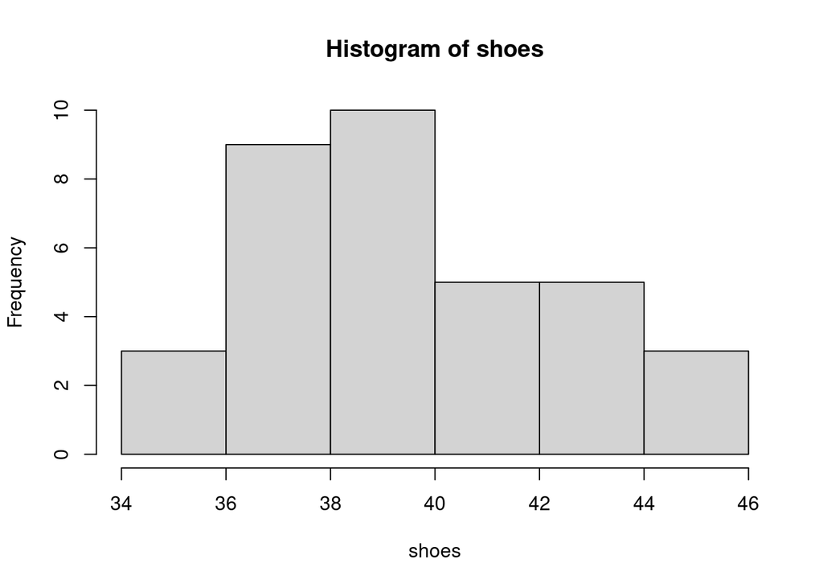

```r
shoes<-data2$shoe_size
hist(shoes)
```

```r
max(shoes)
```

```
## [1] 45
```

Вектор может быть именованным и к каждому элементу тогда можно обратиться по имени:

```r
b<-c("e"=1,"f"=2,"g"=3)
b
```

```
## e f g
## 1 2 3
```

```r
b['f']
```

```
## f
## 2
```

```r
names(b)
```

```
## [1] "e" "f" "g"
```

А если имени нет?

[figure not shown]

Тогда можно по номеру в последовательности

```r
b[2]
```

```
## f
## 2
```

Или сразу по вектору номеров! NB! В R нумерация элементов начинается с 1, но не в каждом языке программирования так.

```r
b[c(1,3)]
```

```
## e g
## 1 3
```

Или по логическому вектору отфильтровать другой вектор:

```r
b[c(TRUE,FALSE,TRUE)]
```

```
## e g
## 1 3
```

Мы можем выбрать не одну, а несколько колонок из таблицы с помощью вектора:

```r
data2[c("eye_color","gorgeous")]
```

```
##    eye_color gorgeous
## 1      green       10
## 2      brown       10
## 3       blue        7
## 4      brown       10
## 5       blue        6
## 6      green       10
## 7      brown        8
## 8      brown        8
## 9      green        7
## 10     green        9
## 11     other        5
## 12     other        4
## 13     green       10
## 14     green        8
```

[output cut: 21 more lines]

### Матрицы

[figure not shown]

Матрица - такая структура данных, где есть столбики и строки. Вектор может быть превращён в матрицу. Для этого надо сказать, сколько в нём строчек или столбиков.

```r
a
```

```
## [1] 1 2 3 3 2 1
```

```r
matrix(a[1:2],nrow=3)
```

```
## Warning in matrix(a[1:2], nrow = 3): data length [2] is not a sub-multiple or
## multiple of the number of rows [3]
```

```
##      [,1]
## [1,]    1
## [2,]    2
## [3,]    1
```

R выдает предупреждение. Видишь, что случилось? Из нашего вектора из двух элементов `a[1:2]` мы создали матрицу с тремя строками. Что будет, если сделать больше строк?

```r
matrix(a[1:2],nrow=6)
```

```
##      [,1]
## [1,]    1
## [2,]    2
## [3,]    1
## [4,]    2
## [5,]    1
## [6,]    2
```

Никакой ругани)) В матрице из раза в раз повторяются 1 и 2 элементы вектора. Не ругается R потому что 6 рядок кратно 2. Так как 3 строки не кратны 2, то ровненько повторить элементы не получилось, о чем R нас предупредил.

Кстати, это была одночастная матрица. Она бывает такой

[figure not shown]

или такой

```r
matrix(a,nrow=2,byrow=TRUE)
```

```
##      [,1] [,2] [,3]
## [1,]    1    2    3
## [2,]    3    2    1
```

А это уже многочастная матрица. Спасибо, Икеа!

[figure not shown]

```r
matrix(a,nrow=2,byrow=FALSE) #что будет?
```

```
##      [,1] [,2] [,3]
## [1,]    1    3    2
## [2,]    2    3    1
```

Как видите, можно заполнять матрицу элементами построчно или по столбцам.

Пустую матрицу тоже можно создать

```r
matrix()
```

```
##      [,1]
## [1,]   NA
```

Тебе, наверняка, известна корреляционная матрица

```r
ddd <- data2[c("height","eye_number","gorgeous")]

cor1<-round(cor(ddd, use="pairwise.complete.obs"),3)
cor1
```

```
##            height eye_number gorgeous
## height      1.000     -0.105   -0.153
## eye_number -0.105      1.000   -0.046
## gorgeous   -0.153     -0.046    1.000
```

К элементам матрицы можно обращаться по координатам:

```r
cor1[1,]
```

```
##     height eye_number   gorgeous
##      1.000     -0.105     -0.153
```

```r
cor1[1,1]
```

```
## [1] 1
```

```r
cor1[c("AGE","APPEAL1")]
```

```
## [1] NA NA
```

```r
dimnames(cor1)
```

```
## [[1]]
## [1] "height"     "eye_number" "gorgeous"
##
## [[2]]
## [1] "height"     "eye_number" "gorgeous"
```

### Списки

Список (list) - структура данных, которая может включать в себя набор из данных разного формата, например, вектор и строку, число и матрицу и пр.

```r
u0 <- list('A', 1)
u0
```

```
## [[1]]
## [1] "A"
##
## [[2]]
## [1] 1
```

Мы можем посмотреть структуру объекта:

```r
u <- list("A", 1, list ("A", T))
str(u)
```

```
## List of 3
##  $ : chr "A"
##  $ : num 1
##  $ :List of 2
##   ..$ : chr "A"
##   ..$ : logi TRUE
```

Представим, что список - это мешочек. Функция `unlist()` вытаскивает предметы из мешочка и просто выставляет их на стол

[figure not shown]

```r
uu <- c(list("a",5),list(list(5)))
str(uu)
```

```
## List of 3
##  $ : chr "a"
##  $ : num 5
##  $ :List of 1
##   ..$ : num 5
```

```r
unlist(u)
```

```
## [1] "A"    "1"    "A"    "TRUE"
```

Можно превратить список в другие структуры данных, например, таблицу или матрицу.

```r
u <- list("a"=c(1,2),"b"=c(3,4))
str(u)
```

```
## List of 2
##  $ a: num [1:2] 1 2
##  $ b: num [1:2] 3 4
```

```r
u2 <- as.data.frame(u)
u3 <- as.matrix(u2)
u4 <- as.matrix(u)
```

Найдите эти переменные в глобальном окружении. Выглядят они похоже, но описания у них в глобальном окружении разные, как и принципы работы с ними.

Элементам списка также можно давать имена, а не обращаться к ним по номерам:

```r
u <- list('a', matrix(c(1, 2)))
names(u) <- c('meow', 'meow_num')
u
```

```
## $meow
## [1] "a"
##
## $meow_num
##      [,1]
## [1,]    1
## [2,]    2
```

Выведем второй элемент списка и посмотрим, какой тип данных он имеет:

```r
u[2]
```

```
## $meow_num
##      [,1]
## [1,]    1
## [2,]    2
```

```r
class(u[2])
```

```
## [1] "list"
```

Второй элемент этого списка был превращен из матрицы с одной колонкой в вертикальный список с именем meow_num, состоящий из одного элемента - матрицы.

Чтобы нам добраться до самого второго элемента именнованного списка - матрицы - нужно использовать двойные скобки `[[x]]`. Это особенность синтаксиса.

```r
u[[2]]
```

```
##      [,1]
## [1,]    1
## [2,]    2
```

```r
class(u[[2]])
```

```
## [1] "matrix" "array"
```

Либо обратиться не по индексу, а по имени:

```r
u$meow
```

```
## [1] "a"
```

[figure not shown]

### Дата фреймы

Это наши любимые таблицы. В каждом столбце находятся элементы одного типа. В переменной data находится наш датафрейм. Как и с векторами, есть три базовых способа фильтрации датафреймов:

1. с помощью вектора с адресами (номерами строк)

```r
data10_1<-data2[1:10,]
```

2. с помощью вектора с именами

```r
data10_1<-data2[c(1:5,7:10),c("soft_drink","hot_drink")]
```

3. С помощью логического вектора (`rep()` - функция, генерирующая повторяющиеся значения)

```r
data10_1<-data2[c(rep(TRUE,10),rep(FALSE,25)),]
```

Подробнее о логической фильтрации будет в следующем уроке.

## Функции и простые действия с данными

Для начала мы можем узнать тип данных, из которых состоит вектор

```r
ch <- c('apple', 'pear', 'banana', 'orange')
ch
```

```
## [1] "apple"  "pear"   "banana" "orange"
```

```r
typeof(ch)
```

```
## [1] "character"
```

Сколько уникальных элементов содержится в векторе?

```r
ch2 <- c('apple', 'pear', 'banana', 'orange', 'apple', 'apple')
unique(ch2)
```

```
## [1] "apple"  "pear"   "banana" "orange"
```

```r
sort(ch2) #сортировка объектов
```

```
## [1] "apple"  "apple"  "apple"  "banana" "orange" "pear"
```

Фильтруем все, что по алфавиту идет раньше ‘ba’. При этом считается, что ‘ba..’ идет позже просто ‘ba’

```r
ch[ch>"ba"]
```

```
## [1] "pear"   "banana" "orange"
```

Сколько символов в элементах вектора?

```r
length(ch)
```

```
## [1] 4
```

```r
nchar(ch)
```

```
## [1] 5 4 6 6
```

Поиск элементов

```r
grep('b', ch, value=TRUE) #дает само значение
```

```
## [1] "banana"
```

```r
grep('b', ch, value=FALSE) #дает порядковый номер элемента
```

```
## [1] 3
```

```r
ch[grep('b', ch, value=FALSE)] #определяет значение по порядковому номеру элемента
```

```
## [1] "banana"
```

Bывод элемента по номеру

```r
ch2[1]
```

```
## [1] "apple"
```

Исключение элемента по номеру

```r
ch2[-4]
```

```
## [1] "apple"  "pear"   "banana" "apple"  "apple"
```

```r
ch[-1]
```

```
## [1] "pear"   "banana" "orange"
```

```r
ch2[-c(1, 2)]
```

```
## [1] "banana" "orange" "apple"  "apple"
```

Разбиение по разделителю (пробел)

```r
text <- 'Ну-ка фрукты встаньте в ряд'
strsplit(text, ' ')
```

```
## [[1]]
## [1] "Ну-ка"    "фрукты"   "встаньте" "в"        "ряд"
```

```r
a <-  strsplit(text, ' ')
typeof(a)
```

```
## [1] "list"
```

```r
typeof(a[1])
```

```
## [1] "list"
```

Строка с пропусками вида character и digit

```r
sprintf("%s отправляется в %d часов", "Электричка", 12)
```

```
## [1] "Электричка отправляется в 12 часов"
```

```r
sprintf("%s отправляется в %d часов", rep("Электричка", 2), c(12, 13))
```

```
## [1] "Электричка отправляется в 12 часов" "Электричка отправляется в 13 часов"
```

Вытащить кусок строки

```r
substr("Я маленькая лошадка", start=3, stop=12)
```

```
## [1] "маленькая "
```

Заменить кусок внутри строки

```r
sub("маленькая", "большая", "Я маленькая лошадка")
```

```
## [1] "Я большая лошадка"
```

```r
sub("маленькая", "большая", "Я маленькая маленькая лошадка") #заменяет только первое появление подстроки
```

```
## [1] "Я большая маленькая лошадка"
```

```r
gsub("маленькая", "большая", "Я маленькая маленькая лошадка")
```

```
## [1] "Я большая большая лошадка"
```

Отбор элементов по номеру позиции (индекс) и по его значению

```r
d <- c(1,2,6,4)
d>2
```

```
## [1] FALSE FALSE  TRUE  TRUE
```

```r
d[d>2] #сами элементы
```

```
## [1] 6 4
```

```r
which(d>2) #номера их позиций
```

```
## [1] 3 4
```

Можно проверить, принадлежат ли элементы вектора определенному типу данных

```r
int_num<-c(1,2,3,4000)
is.integer(int_num)
```

```
## [1] FALSE
```

```r
typeof(int_num)
```

```
## [1] "double"
```

К целочисленному выражению элементы вектора можно привести несколькими способами:

```r
int_num<-as.integer(c(1,2,3,4000))
int_num<-c(1L,2L,3L,4000L) #сохраняет как целые
as.integer(214748364.7)
```

```
## [1] 214748364
```

```r
as.integer(2147483648) #слишком большое число, не может хранить
```

```
## [1] NA
```

```r
as.integer(-2147483647)
```

```
## [1] -2147483647
```

```r
as.integer(-2147483648)
```

```
## [1] NA
```

Для больших чисел мы вынуждены использовать формат с плавающей точкой, он может хранить больше информации

```r
as.double("10000998843483274893274892374238947273")
```

```
## [1] 1.0001e+37
```

```r
options(scipen=999)
2^64
```

```
## [1] 18446744073709551616
```

```r
90071992547409923
```

```
## [1] 90071992547409920
```

```r
options(scipen=0)
2^64
```

```
## [1] 1.844674e+19
```

```r
90071992547409923
```

```
## [1] 9.007199e+16
```

Numeric - общее название для числовых данных, включает в себя и double, и integer. Подробнее о форматах можно посмотреть в справке `?double` и `?integer`.

```r
numeric_num<-c(1,2,2.5)
is.integer(numeric_num)
```

```
## [1] FALSE
```

```r
is.integer(int_num)
```

```
## [1] TRUE
```

```r
is.numeric(int_num)
```

```
## [1] TRUE
```

```r
is.numeric(numeric_num)
```

```
## [1] TRUE
```

```r
str(numeric_num)
```

```
##  num [1:3] 1 2 2.5
```

```r
is.double(numeric_num)
```

```
## [1] TRUE
```

```r
typeof(numeric_num)
```

```
## [1] "double"
```

Объединение векторов с разнымм типами значений

```r
n <- c(1,2,3)
s <- c('a', 'b', 'c')
c(n,s)
```

```
## [1] "1" "2" "3" "a" "b" "c"
```

Как видите, при объединении числовой формат был переделан в строковый. Как мы узнали ранее, разные форматы можно хранить только в списках и таблицах.

## Задания для тренировки

1. Соедини значение 1 и TRUE в вектор. Что получилось?
2. У тебя есть вектор `a <-c(1, 2, 3, 4, 5, 6, 7, 8, 9, 10)`. Создай из него матрицу с заполнением по строкам. Выбери первый столбец. Помни, что при фильтрации в формате `vec[x, y]`, `x`- это строка, `y` - это столбец.
3. Список со вложенными списками `subjects <- list(list(‘Masha’, 18, list(39, 40)), list(‘Nastya’, 22, 41), list(‘Mitya’, 25, 46))`. Выведи второй элемент третьего элемента первого списка. Что это за число? Поэкспериментируй. Не забудь про двойные кавычки `[[]]`.
4. Определи среднее, сумму, максимальное и минимальное значение в векторе `data2$hair_length`. Нарисуй гистограмму.
5. Выведи вектор, получившийся в результате проверки каждого элемента из `data2$hair_length` на четность/нечетность (используй остаток от целочисленного деления)
6. Из нашей таблицы data выбери элемент, находящийся на 18 строке в 6 столбце и выведи на экран с помощью функции `paste()`